# Titanic EDA

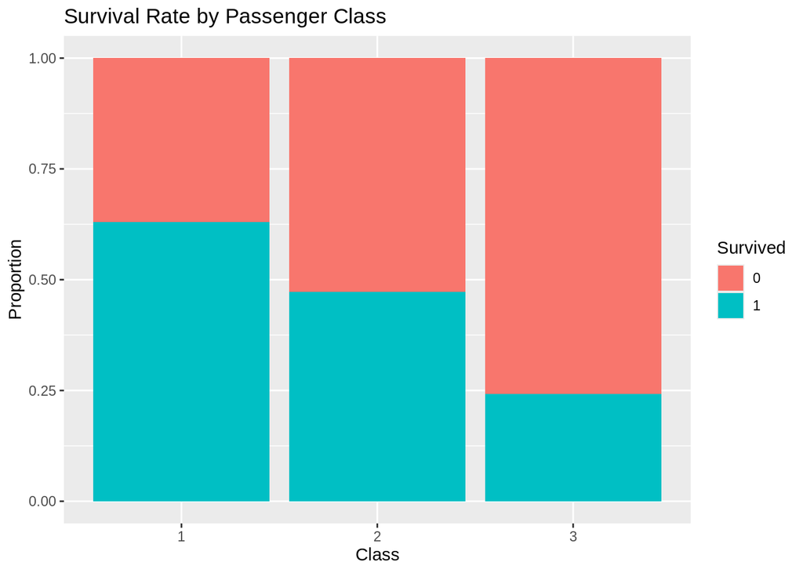

```r
#Plot Survival by class
ggplot(clean_data, aes(x = factor(Pclass), fill = factor(Survived))) +
     geom_bar(position = "fill") +
     labs(title = "Survival Rate by Passenger Class", x = "Class", y = "Proportion", fill = "Survived")
```

Passenger class was a strong indicator of survival. First-class passengers had significantly higher survival rates compared to those in second and third class, likely due to their proximity to lifeboats and priority during evacuation.

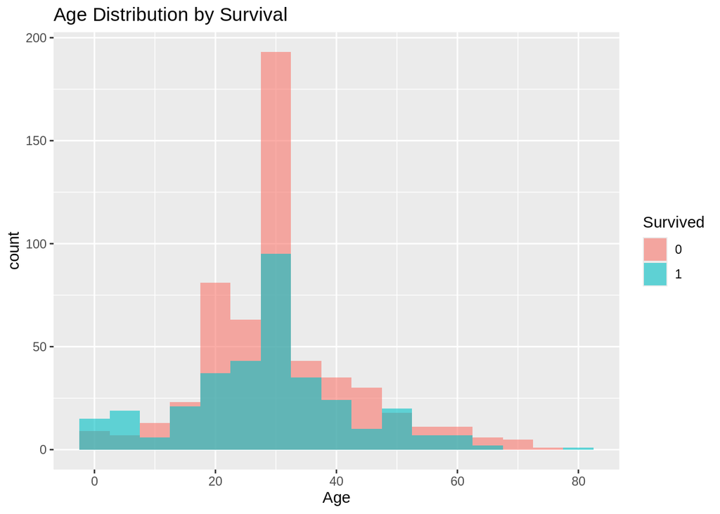

```r
#Plot Age distribution by Survival
ggplot(clean_data, aes(x = Age, fill = factor(Survived))) +
     geom_histogram(binwidth = 5, position = "identity", alpha = 0.6) +
     labs(title = "Age Distribution by Survival", x = "Age", fill = "Survived")
```

The most common age range on board was around 20 to 30 years old, but this group had a relatively low survival rate. In contrast, children under 10 had noticeably higher survival rates, likely due to evacuation priorities. The plot suggests that while young adults made up a large portion of passengers, they were not prioritized during rescue efforts as much as women or children.

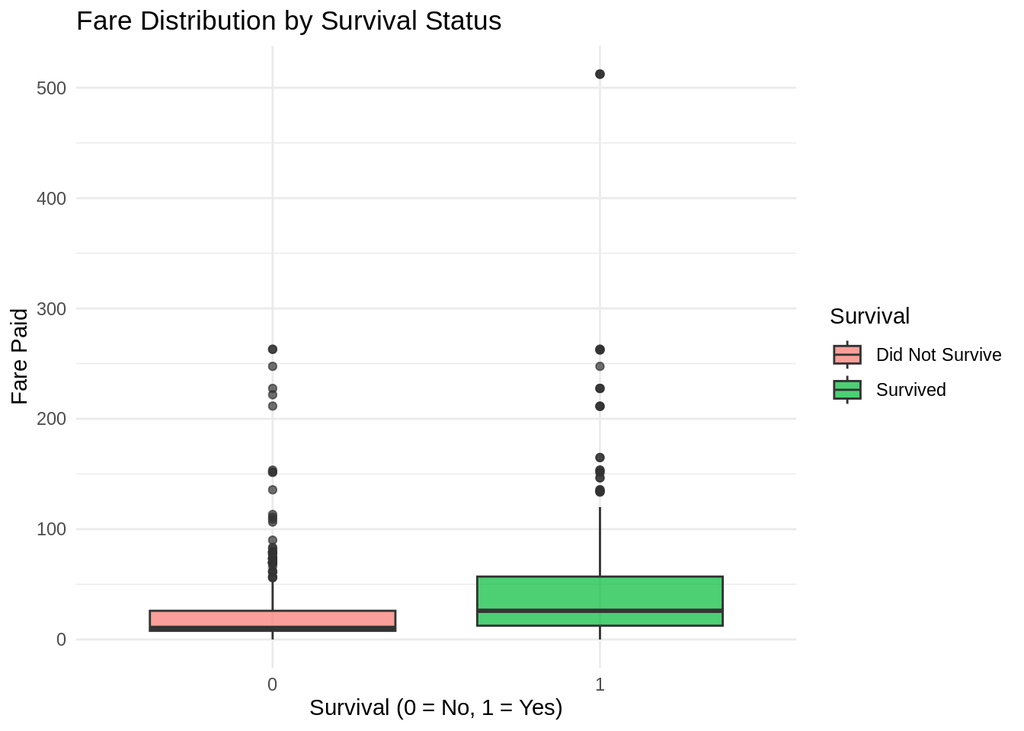

```r
#Plot Fare Vs Survival
ggplot(clean_data, aes(x = factor(Survived), y = Fare, fill = factor(Survived))) +
   geom_boxplot(alpha = 0.7) +
   scale_fill_manual(values = c("0" = "#F8766D", "1" = "#00BA38"),
                     labels = c("0" = "Did Not Survive", "1" = "Survived")) +         labs(
        title = "Fare Distribution by Survival Status",
         x = "Survival (0 = No, 1 = Yes)",
         y = "Fare Paid",
         fill = "Survival"
     ) +
     theme_minimal()
```

There is a clear positive association between fare amount and survival probability. Passengers who paid higher fares — generally associated with first-class accommodations — exhibited significantly higher survival rates. This trend suggests that socioeconomic status, as represented by fare paid, played a critical role in access to life-saving resources, likely due to cabin location proximity to lifeboats and preferential treatment during evacuation protocols.

CONCLUSION: This exploratory analysis of the Titanic dataset reveals several key factors that influenced passenger survival:

Age: Children, especially those under 10, had higher survival rates, while the most common age group (20–30 years old) had relatively low survival rates.

Passenger Class: First-class passengers had a distinct survival advantage compared to those in second or third class, suggesting that cabin location and evacuation priority were influenced by class.

Fare: Passengers who paid higher fares were more likely to survive, reinforcing the impact of socioeconomic status on survival outcomes.

Overall, survival was not random — it was strongly correlated with demographic and socioeconomic variables, highlighting inequalities in access to safety during the disaster.